# Reproducible Research - Course Project 1

Wesley Klabbers

3 June 2016

This document provides a step-by-step approach to conduct Course Project 1 of Coursera’s Reproducible Research Course.

### Reading and Formatting the Dataset

The following chunk of code reads in a dataset that contains one individual’s movements in terms of steps taken for a period of 2 months on a 5-minute interval basis. Should the dataset already exist, it will not be read in again.

```r
if (!exists("activity")){
    data <- read.csv("activity.csv")
}
```

### What is the mean total number of steps taken per day?

In order to answer this question we want to have a more useful aggregation of the data. At this moment there are multiple records for the same day (due to the 5 minute intervals), which is not tidy. The following chunk of code aggregates this to a daily measure, while excluding all missing data.

```r
dailyaggregate <- aggregate(steps ~ date, data = data, sum, na.rm = TRUE)
```

Subsequently we want to visualize the daily totals in a histogram.

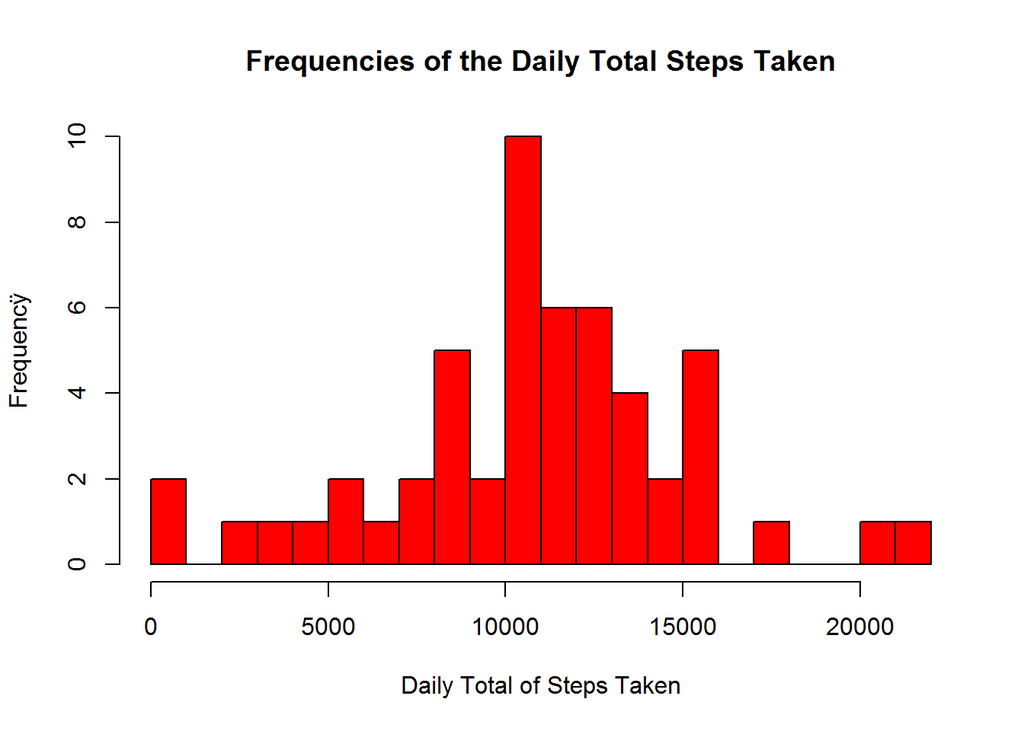

```r
hist(x = dailyaggregate$steps, col = "red", breaks = 20,
     xlab = "Daily Total of Steps Taken", ylab = "Frequencÿ",
     main = "Frequencies of the Daily Total Steps Taken")
```

Lastly, we want to know the mean and median of the total number of steps taken per day.

```r
meansteps <- mean(dailyaggregate$steps, na.rm = TRUE)
mediansteps <- median(dailyaggregate$steps, na.rm = TRUE)
meansteps
```

```
## [1] 10766.19
```

```r
mediansteps
```

```
## [1] 10765
```

### What is the average daily activity pattern?

In order to find the average daily activity pattern we first need to create a new aggregation, this time based on interval rather than date.

```r
intervalaggregate <- aggregate(steps ~ interval, data = data, mean,
                               na.rm = TRUE)
```

Now we can again create a plot to visualize the average steps taken per interval.

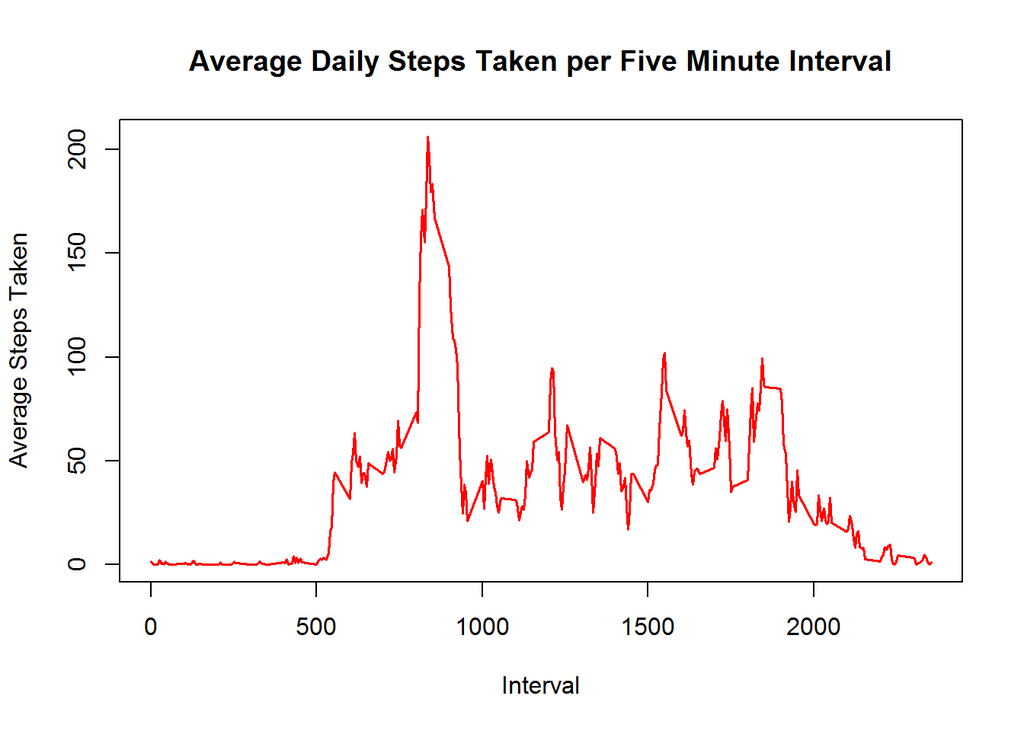

```r
plot(intervalaggregate$interval, intervalaggregate$steps, type = "l",
     col = "red", lwd = 1.5,
     xlab = "Interval", ylab = "Average Steps Taken",
     main = "Average Daily Steps Taken per Five Minute Interval")
```

Additionally, we want to find out which interval has the maximum number of steps.

```r
intervalaggregate[which.max(intervalaggregate$steps),]
```

```
##     interval    steps
## 104      835 206.1698
```

### Imputing Missing Values

Some days and/or intervals have missing values indicated by “NA”. This may introduce unwanted bias into our analyses. We have to carefully consider these NA’s and check what we can do with them.

First, it is a good idea to get an idea of how many NAs there are in the dataset.

```r
sum(is.na(data$steps))
```

```
## [1] 2304
```

One can make very sophisticated calculations when it comes to these missing values. However, to keep it simple, we will impute missing values based on the mean for the specific 5-minute interval.

```r
fixdata <- data
missingdata <- is.na(fixdata$steps)
meaninterval <- tapply(fixdata$steps, fixdata$interval, mean, na.rm = TRUE,
                       simplify = TRUE)
fixdata$steps[missingdata] <- meaninterval[as.character(fixdata$interval[missingdata])]
```

One must check whether the imputing procedure has been done correctly.

```r
sum(is.na(fixdata$steps))
```

```
## [1] 0
```

Now lets re-visualize the results, this time with the imputed values in place.

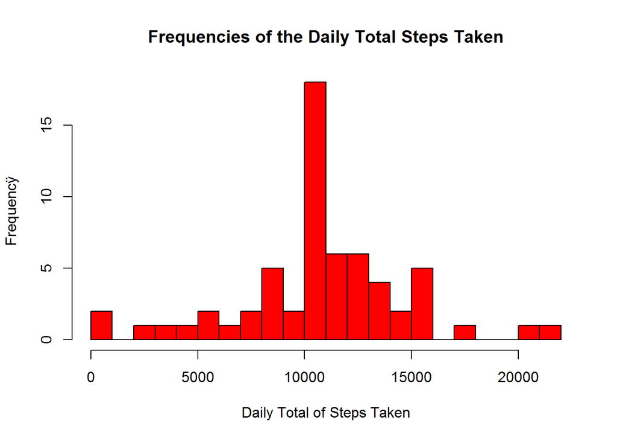

```r
newdailyaggregate <- aggregate(steps ~ date, data = fixdata, sum, na.rm = TRUE)
hist(x = newdailyaggregate$steps, col = "red", breaks = 20,
     xlab = "Daily Total of Steps Taken", ylab = "Frequencÿ",
     main = "Frequencies of the Daily Total Steps Taken")
```

Lets also compare the new median and mean

```r
newmeansteps <- mean(newdailyaggregate$steps, na.rm = TRUE)
newmediansteps <- median(newdailyaggregate$steps, na.rm = TRUE)
newmeansteps
```

```
## [1] 10766.19
```

```r
newmediansteps
```

```
## [1] 10766.19
```

In essence, by imputing missing values based on the average of the 5-minute interval periods led to a change in the median of the total number of steps taken per day. It now equals the mean, which was not the case before.

### Are there differences in activity patterns between weekdays and weekends?

First off, we have to ascertain which dates are weekdays and which are weekends. To do this, lets first convert the data variable to an actual data field.

```r
fixdata$date <- as.POSIXlt(data$date, format = "%Y-%m-%d")
```

Moreover, lets create variables indicating whether the date is a weekend or not.

```r
fixdata$day <- weekdays(fixdata$date)
fixdata$weekend <- as.factor(ifelse(fixdata$day == "Saturday" | fixdata$day == "Sunday", "Weekend", "Weekday"))
```

Making differences in activity patterns visible can be done in many ways. The easiest way would again be a plot.

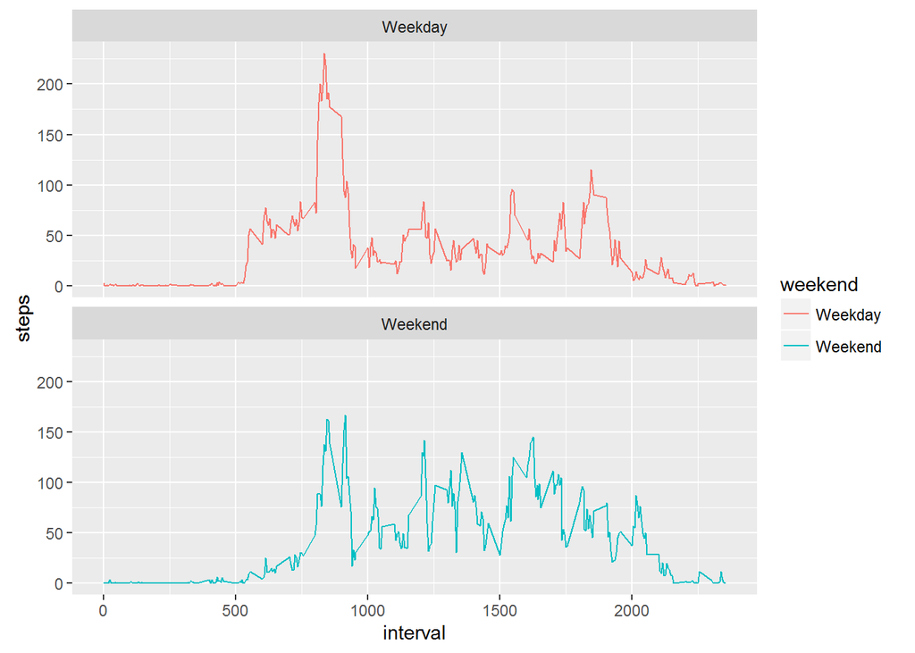

```r
library(ggplot2)
newintervalaggregate <- aggregate(steps ~ weekend + interval, data = fixdata,
                                  mean, na.rm = TRUE)
finplot <- ggplot(newintervalaggregate, aes(x = interval, y = steps,
                                            color = weekend)) +
                                            geom_line() +
                                            facet_wrap( ~ weekend, ncol = 1,
                                                        nrow = 2)
print(finplot)
```

Judging from the plots, one can state that weekday activities start earlier. Moreover, in the weekends there is a higher level of activity during the day than is the case for weekdays.